# Combining depRS and PRS for longitudinal depression

This script contains the longitudinal analyses that will be included in the main manuscript. Cross-sectional depRS for baseline and year 2 data were trained on (standardised) CBCL DSM5-oriented depression subscale scores, PRS were based on the MDD3 GWAS. All continuous variables have been mean centred and standardised for comparison of effect sizes. Longitudinal outcomes examined here are **CBCL DSM-5 oriented depression subscale** at (a) Year 3 and (b) Year 4, and **Lifetime MDD status** at Year 2 which was either (c) Self-reported or (d) Parent-reported. Longitudinal analyses of depRS at year 2 looked at e) Year 3 CBCL and (f) Year 4 CBCL.

# Baseline depRS

PRS data based on MDD3 GWAS (from Poppy) were available for 4161 participants.

## (a) Y3 CBCL Depression

At year 3, CBCL data were available for 8306 participants. A total of 2818 participants have year 3 CBCL data, PRS and baseline envRS.  
Model comparisons are run for:  
m1 = cbcl ~ depRS  
m2 = cbcl ~ depRS + PRS  
m3 = cbcl ~ depRS*PRS

### Performance metrics

| Name | Model | AIC (weights) | AICc (weights) | BIC (weights) | R2 | R2 (adj.) | RMSE | Sigma |
| --- | --- | --- | --- | --- | --- | --- | --- | --- |
| m1 | lm | 7902.5 (<.001) | 7902.5 (<.001) | 7920.3 (0.023) | 0.106 | 0.106 | 0.983 | 0.984 |
| m2 | lm | 7892.5 (0.011) | 7892.5 (0.011) | 7916.3 (0.169) | 0.110 | 0.110 | 0.981 | 0.982 |
| m3 | lm | 7883.4 (0.989) | 7883.5 (0.989) | 7913.2 (0.809) | 0.114 | 0.113 | 0.979 | 0.980 |

### Model comparisons

| Name | Model | BF | df | df_diff | Chi2 | p |
| --- | --- | --- | --- | --- | --- | --- |
| m1 | lm |  | 3 |  |  |  |
| m2 | lm | 7.38 | 4 | 1.000 | 11.941 | < .001 |
| m3 | lm | 4.79 | 5 | 1.000 | 11.078 | < .001 |

Models were detected as nested (in terms of fixed parameters) and are compared in sequential order.

### Estimates

|  | m1 |  |  |  | m2 |  |  |  | m3 |  |  |  |
| --- | --- | --- | --- | --- | --- | --- | --- | --- | --- | --- | --- | --- |
| Predictors | Estimates | std. Error | Statistic | p | Estimates | std. Error | Statistic | p | Estimates | std. Error | Statistic | p |
| (Intercept) | 0.11 (0.07 – 0.15) | 0.02 | 5.86 | **<0.001** | 0.11 (0.07 – 0.15) | 0.02 | 5.88 | **<0.001** | 0.10 (0.06 – 0.14) | 0.02 | 5.42 | **<0.001** |
| depRS b | 0.36 (0.33 – 0.40) | 0.02 | 18.31 | **<0.001** | 0.36 (0.32 – 0.40) | 0.02 | 17.83 | **<0.001** | 0.35 (0.31 – 0.39) | 0.02 | 17.39 | **<0.001** |
| PRS |  |  |  |  | 0.06 (0.03 – 0.10) | 0.02 | 3.46 | **0.001** | 0.07 (0.03 – 0.11) | 0.02 | 3.80 | **<0.001** |
| depRS b × PRS |  |  |  |  |  |  |  |  | 0.07 (0.03 – 0.11) | 0.02 | 3.33 | **0.001** |
| Observations | 2816 |  |  |  | 2816 |  |  |  | 2816 |  |  |  |
| R<sup>2</sup> / R<sup>2</sup> adjusted | 0.106 / 0.106 |  |  |  | 0.110 / 0.110 |  |  |  | 0.114 / 0.113 |  |  |  |

| model | Accuracy | SE | CI | CI_low | CI_high | Method |
| --- | --- | --- | --- | --- | --- | --- |
| m1 | 0.325 | 0.038 | 0.95 | 0.289 | 0.380 | Correlation between observed and predicted |
| m2 | 0.328 | 0.043 | 0.95 | 0.285 | 0.379 | Correlation between observed and predicted |
| m3 | 0.332 | 0.065 | 0.95 | 0.279 | 0.426 | Correlation between observed and predicted |

## (b) Y4 CBCL Depression

At year 4, CBCL data were available for 3807 participants. A total 1357 participants have year 4 CBCL data, PRS and baseline envRS.  
Model comparisons are run for:  
m1 = cbcl ~ envRS  
m2 = cbcl ~ envRS + PRS  
m3 = cbcl ~ envRS*PRS

### Performance metrics

| Name | Model | AIC (weights) | AICc (weights) | BIC (weights) | R2 | R2 (adj.) | RMSE | Sigma |
| --- | --- | --- | --- | --- | --- | --- | --- | --- |
| m1 | lm | 3688.2 (0.011) | 3688.3 (0.012) | 3703.9 (0.174) | 0.063 | 0.063 | 0.940 | 0.940 |
| m2 | lm | 3680.0 (0.719) | 3680.0 (0.720) | 3700.8 (0.804) | 0.071 | 0.069 | 0.936 | 0.937 |
| m3 | lm | 3681.9 (0.269) | 3682.0 (0.268) | 3708.0 (0.022) | 0.071 | 0.069 | 0.936 | 0.938 |

### Model comparisons

| Name | Model | BF | df | df_diff | Chi2 | p |
| --- | --- | --- | --- | --- | --- | --- |
| m1 | lm |  | 3 |  |  |  |
| m2 | lm | 4.63 | 4 | 1.000 | 10.278 | 0.001 |
| m3 | lm | 0.028 | 5 | 1.000 | 0.037 | 0.848 |

Models were detected as nested (in terms of fixed parameters) and are compared in sequential order.

### Estimates

|  | m1 |  |  |  | m2 |  |  |  | m3 |  |  |  |
| --- | --- | --- | --- | --- | --- | --- | --- | --- | --- | --- | --- | --- |
| Predictors | Estimates | std. Error | Statistic | p | Estimates | std. Error | Statistic | p | Estimates | std. Error | Statistic | p |
| (Intercept) | 0.05 (-0.00 – 0.10) | 0.03 | 1.92 | 0.055 | 0.05 (-0.00 – 0.10) | 0.03 | 1.93 | 0.054 | 0.05 (-0.00 – 0.10) | 0.03 | 1.88 | 0.061 |
| depRS b | 0.27 (0.22 – 0.33) | 0.03 | 9.58 | **<0.001** | 0.26 (0.20 – 0.31) | 0.03 | 9.09 | **<0.001** | 0.26 (0.20 – 0.31) | 0.03 | 9.02 | **<0.001** |
| PRS |  |  |  |  | 0.08 (0.03 – 0.13) | 0.03 | 3.21 | **0.001** | 0.08 (0.03 – 0.13) | 0.03 | 3.20 | **0.001** |
| depRS b × PRS |  |  |  |  |  |  |  |  | 0.01 (-0.05 – 0.06) | 0.03 | 0.19 | 0.848 |
| Observations | 1357 |  |  |  | 1357 |  |  |  | 1357 |  |  |  |
| R<sup>2</sup> / R<sup>2</sup> adjusted | 0.063 / 0.063 |  |  |  | 0.071 / 0.069 |  |  |  | 0.071 / 0.069 |  |  |  |

| model | Accuracy | SE | CI | CI_low | CI_high | Method |
| --- | --- | --- | --- | --- | --- | --- |
| m1 | 0.255 | 0.074 | 0.95 | 0.213 | 0.371 | Correlation between observed and predicted |
| m2 | 0.264 | 0.076 | 0.95 | 0.179 | 0.366 | Correlation between observed and predicted |
| m3 | 0.267 | 0.042 | 0.95 | 0.201 | 0.296 | Correlation between observed and predicted |

## (c) 2-year lifetime MDD diagnosis (youth)

For depRS-only analyses, there are 238 lifetime MDD cases, 33 current MDD cases and 407 cases with lifetime diagnoses of a depressive disorder (Major Depressive Disorder, Persistent Depressive Disorder (dysthymia), Depressive Disorder Unspecified).  
Of those with both envRS and PRS at Y2 (N = 2982), there are 77 lifetime MDD cases, 7 current MDD cases and 150 cases with lifetime diagnoses of a depressive disorder (Major Depressive Disorder, Persistent Depressive Disorder (dysthymia), Depressive Disorder Unspecified).

### depRS only

|  | mdd_lifetime |  |  |  |
| --- | --- | --- | --- | --- |
| Predictors | Odds Ratios | std. Error | Statistic | p |
| (Intercept) | 0.03 (0.03 – 0.04) | 0.00 | -48.86 | **<0.001** |
| depRS b | 1.49 (1.34 – 1.65) | 0.08 | 7.52 | **<0.001** |
| Observations | 7033 |  |  |  |
| R<sup>2</sup> Tjur | 0.008 |  |  |  |

| Accuracy | SE | CI | CI_low | CI_high | Method |
| --- | --- | --- | --- | --- | --- |
| 0.636 | 0.031 | 0.95 | 0.597 | 0.677 | Area under Curve |

### Performance metrics

| Name | Model | AIC (weights) | AICc (weights) | BIC (weights) | Tjur’s R2 | RMSE | Sigma | Log_loss | Score_log | Score_spherical | PCP |
| --- | --- | --- | --- | --- | --- | --- | --- | --- | --- | --- | --- |
| Model 1 | glm | 694.9 (0.111) | 694.9 (0.112) | 706.9 (0.802) | 0.011 | 0.158 | 1.000 | 0.116 | -2.004 | 0.016 | 0.950 |
| Model 2 | glm | 691.8 (0.534) | 691.8 (0.534) | 709.8 (0.191) | 0.012 | 0.158 | 1.000 | 0.115 | -2.006 | 0.015 | 0.950 |
| Model 3 | glm | 692.6 (0.355) | 692.6 (0.354) | 716.6 (0.006) | 0.013 | 0.158 | 1.000 | 0.115 | -2.005 | 0.015 | 0.950 |

### Model comparisons

| Name | Model | BF | df | df_diff | Chi2 | p |
| --- | --- | --- | --- | --- | --- | --- |
| Model 1 | glm |  | 2 |  |  |  |
| Model 2 | glm | 0.239 | 3 | 1.000 | 5.135 | 0.023 |
| Model 3 | glm | 0.033 | 4 | 1.000 | 1.182 | 0.277 |

Models were detected as nested (in terms of fixed parameters) and are compared in sequential order.

### Estimates

|  | m1 |  |  |  | m2 |  |  |  | m3 |  |  |  |
| --- | --- | --- | --- | --- | --- | --- | --- | --- | --- | --- | --- | --- |
| Predictors | Odds Ratios | std. Error | Statistic | p | Odds Ratios | std. Error | Statistic | p | Odds Ratios | std. Error | Statistic | p |
| (Intercept) | 0.02 (0.02 – 0.03) | 0.00 | -30.02 | **<0.001** | 0.02 (0.02 – 0.03) | 0.00 | -29.38 | **<0.001** | 0.02 (0.02 – 0.03) | 0.00 | -28.99 | **<0.001** |
| depRS b | 1.66 (1.37 – 2.00) | 0.16 | 5.30 | **<0.001** | 1.62 (1.33 – 1.95) | 0.16 | 4.97 | **<0.001** | 1.68 (1.37 – 2.04) | 0.17 | 5.11 | **<0.001** |
| PRS |  |  |  |  | 1.31 (1.04 – 1.65) | 0.15 | 2.26 | **0.024** | 1.37 (1.07 – 1.75) | 0.17 | 2.49 | **0.013** |
| depRS b × PRS |  |  |  |  |  |  |  |  | 0.89 (0.73 – 1.09) | 0.09 | -1.09 | 0.278 |
| Observations | 2982 |  |  |  | 2982 |  |  |  | 2982 |  |  |  |
| R<sup>2</sup> Tjur | 0.011 |  |  |  | 0.012 |  |  |  | 0.013 |  |  |  |

| model | Accuracy | SE | CI | CI_low | CI_high | Method |
| --- | --- | --- | --- | --- | --- | --- |
| 1 | 0.652 | 0.071 | 0.95 | 0.542 | 0.706 | Area under Curve |
| 2 | 0.665 | 0.032 | 0.95 | 0.637 | 0.712 | Area under Curve |
| 3 | 0.655 | 0.043 | 0.95 | 0.601 | 0.699 | Area under Curve |

### ROC curves

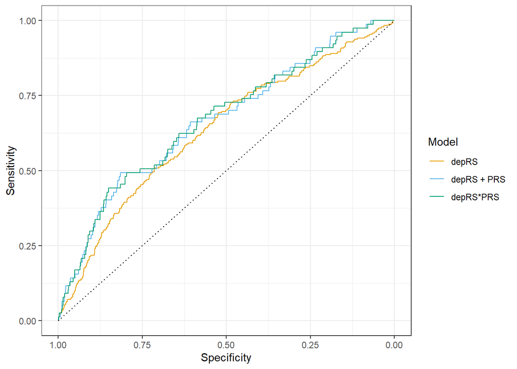

## (d) 2-year lifetime MDD diagnosis (parent)

For depRS-only analyses, there are 276 lifetime MDD cases, 32 current MDD cases and 555 cases with lifetime diagnoses of a depressive disorder (Major Depressive Disorder, Persistent Depressive Disorder (dysthymia), Depressive Disorder Unspecified).  
Of those with both envRS and PRS at Y2 (N = 2957), there are 118 lifetime MDD cases, 19 current MDD cases and 252 cases with lifetime diagnoses of a depressive disorder (Major Depressive Disorder, Persistent Depressive Disorder (dysthymia), Depressive Disorder Unspecified).

### depRS only

|  | mdd_lifetime |  |  |  |
| --- | --- | --- | --- | --- |
| Predictors | Odds Ratios | std. Error | Statistic | p |
| (Intercept) | 0.04 (0.03 – 0.04) | 0.00 | -48.53 | **<0.001** |
| depRS b | 1.75 (1.60 – 1.93) | 0.08 | 11.79 | **<0.001** |
| Observations | 6953 |  |  |  |
| R<sup>2</sup> Tjur | 0.024 |  |  |  |

| Accuracy | SE | CI | CI_low | CI_high | Method |
| --- | --- | --- | --- | --- | --- |
| 0.681 | 0.017 | 0.95 | 0.664 | 0.699 | Area under Curve |

### Performance metrics

| Name | Model | AIC (weights) | AICc (weights) | BIC (weights) | Tjur’s R2 | RMSE | Sigma | Log_loss | Score_log | Score_spherical | PCP |
| --- | --- | --- | --- | --- | --- | --- | --- | --- | --- | --- | --- |
| Model 1 | glm | 933.2 (0.254) | 933.2 (0.255) | 945.2 (0.904) | 0.031 | 0.193 | 1.000 | 0.157 | -4.822 | 0.013 | 0.926 |
| Model 2 | glm | 931.8 (0.526) | 931.8 (0.526) | 949.7 (0.094) | 0.032 | 0.193 | 1.000 | 0.157 | -4.826 | 0.012 | 0.926 |
| Model 3 | glm | 933.5 (0.220) | 933.5 (0.219) | 957.5 (0.002) | 0.032 | 0.193 | 1.000 | 0.156 | -4.823 | 0.012 | 0.926 |

### Model comparisons

| Name | Model | BF | df | df_diff | Chi2 | p |
| --- | --- | --- | --- | --- | --- | --- |
| Model 1 | glm |  | 2 |  |  |  |
| Model 2 | glm | 0.104 | 3 | 1.000 | 3.457 | 0.063 |
| Model 3 | glm | 0.021 | 4 | 1.000 | 0.254 | 0.614 |

Models were detected as nested (in terms of fixed parameters) and are compared in sequential order.

### Estimates

|  | m1 |  |  |  | m2 |  |  |  | m3 |  |  |  |
| --- | --- | --- | --- | --- | --- | --- | --- | --- | --- | --- | --- | --- |
| Predictors | Odds Ratios | std. Error | Statistic | p | Odds Ratios | std. Error | Statistic | p | Odds Ratios | std. Error | Statistic | p |
| (Intercept) | 0.04 (0.03 – 0.04) | 0.00 | -31.66 | **<0.001** | 0.04 (0.03 – 0.04) | 0.00 | -31.38 | **<0.001** | 0.04 (0.03 – 0.04) | 0.00 | -31.25 | **<0.001** |
| depRS b | 1.91 (1.64 – 2.23) | 0.15 | 8.37 | **<0.001** | 1.88 (1.61 – 2.19) | 0.15 | 8.05 | **<0.001** | 1.90 (1.62 – 2.23) | 0.15 | 7.89 | **<0.001** |
| PRS |  |  |  |  | 1.20 (0.99 – 1.45) | 0.12 | 1.86 | 0.063 | 1.22 (0.99 – 1.51) | 0.13 | 1.90 | 0.058 |
| depRS b × PRS |  |  |  |  |  |  |  |  | 0.96 (0.82 – 1.13) | 0.08 | -0.50 | 0.615 |
| Observations | 2957 |  |  |  | 2957 |  |  |  | 2957 |  |  |  |
| R<sup>2</sup> Tjur | 0.031 |  |  |  | 0.032 |  |  |  | 0.032 |  |  |  |

| model | Accuracy | SE | CI | CI_low | CI_high | Method |
| --- | --- | --- | --- | --- | --- | --- |
| 1 | 0.690 | 0.067 | 0.95 | 0.635 | 0.786 | Area under Curve |
| 2 | 0.702 | 0.063 | 0.95 | 0.635 | 0.764 | Area under Curve |
| 3 | 0.703 | 0.048 | 0.95 | 0.666 | 0.775 | Area under Curve |

### ROC curves

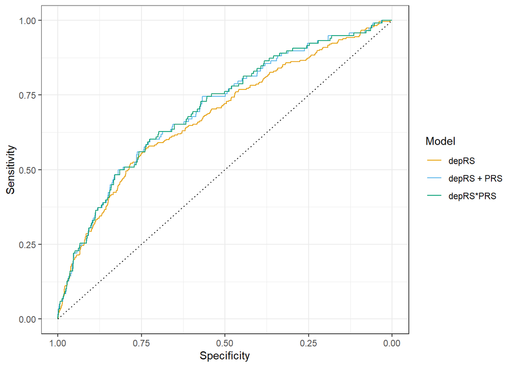

# Year 2 depRS

## Y3 CBCL Depression

using year 2 envRS scores.

At year 3, CBCL data were available for 8306 participants. A total of 2332 participants have year 3 CBCL data, PRS and baseline envRS.  
Model comparisons are run for:  
m1 = cbcl ~ depRS  
m2 = cbcl ~ depRS + PRS  
m3 = cbcl ~ depRS*PRS

### Performance metrics

| Name | Model | AIC (weights) | AICc (weights) | BIC (weights) | R2 | R2 (adj.) | RMSE | Sigma |
| --- | --- | --- | --- | --- | --- | --- | --- | --- |
| m1 | lm | 6151.0 (0.437) | 6151.0 (0.438) | 6168.3 (0.950) | 0.207 | 0.207 | 0.905 | 0.905 |
| m2 | lm | 6151.2 (0.398) | 6151.2 (0.397) | 6174.2 (0.049) | 0.208 | 0.207 | 0.904 | 0.905 |
| m3 | lm | 6153.0 (0.165) | 6153.0 (0.165) | 6181.7 (0.001) | 0.208 | 0.207 | 0.904 | 0.905 |

### Model comparisons

| Name | Model | BF | df | df_diff | Chi2 | p |
| --- | --- | --- | --- | --- | --- | --- |
| m1 | lm |  | 3 |  |  |  |
| m2 | lm | 0.051 | 4 | 1.000 | 1.811 | 0.178 |
| m3 | lm | 0.023 | 5 | 1.000 | 0.246 | 0.620 |

Models were detected as nested (in terms of fixed parameters) and are compared in sequential order.

### Estimates

|  | m1 |  |  |  | m2 |  |  |  | m3 |  |  |  |
| --- | --- | --- | --- | --- | --- | --- | --- | --- | --- | --- | --- | --- |
| Predictors | Estimates | std. Error | Statistic | p | Estimates | std. Error | Statistic | p | Estimates | std. Error | Statistic | p |
| (Intercept) | 0.07 (0.03 – 0.10) | 0.02 | 3.58 | **<0.001** | 0.07 (0.03 – 0.10) | 0.02 | 3.62 | **<0.001** | 0.07 (0.03 – 0.10) | 0.02 | 3.53 | **<0.001** |
| depRS y2 | 0.88 (0.81 – 0.95) | 0.04 | 24.68 | **<0.001** | 0.87 (0.80 – 0.94) | 0.04 | 24.31 | **<0.001** | 0.87 (0.80 – 0.94) | 0.04 | 24.27 | **<0.001** |
| PRS |  |  |  |  | 0.03 (-0.01 – 0.06) | 0.02 | 1.35 | 0.179 | 0.03 (-0.01 – 0.06) | 0.02 | 1.36 | 0.174 |
| depRS y2 × PRS |  |  |  |  |  |  |  |  | 0.02 (-0.05 – 0.09) | 0.04 | 0.50 | 0.620 |
| Observations | 2330 |  |  |  | 2330 |  |  |  | 2330 |  |  |  |
| R<sup>2</sup> / R<sup>2</sup> adjusted | 0.207 / 0.207 |  |  |  | 0.208 / 0.207 |  |  |  | 0.208 / 0.207 |  |  |  |

| model | Accuracy | SE | CI | CI_low | CI_high | Method |
| --- | --- | --- | --- | --- | --- | --- |
| m1 | 0.457 | 0.027 | 0.95 | 0.419 | 0.480 | Correlation between observed and predicted |
| m2 | 0.452 | 0.069 | 0.95 | 0.383 | 0.544 | Correlation between observed and predicted |
| m3 | 0.457 | 0.052 | 0.95 | 0.400 | 0.528 | Correlation between observed and predicted |

## Y4 CBCL Depression

At year 4, CBCL data were available for 3807 participants. A total 1260 participants have year 4 CBCL data, PRS and baseline envRS.  
Model comparisons are run for:  
m1 = cbcl ~ envRS  
m2 = cbcl ~ envRS + PRS  
m3 = cbcl ~ envRS*PRS

### Performance metrics

| Name | Model | AIC (weights) | AICc (weights) | BIC (weights) | R2 | R2 (adj.) | RMSE | Sigma |
| --- | --- | --- | --- | --- | --- | --- | --- | --- |
| m1 | lm | 3340.4 (0.205) | 3340.5 (0.206) | 3355.9 (0.817) | 0.148 | 0.147 | 0.909 | 0.909 |
| m2 | lm | 3338.4 (0.581) | 3338.4 (0.582) | 3358.9 (0.178) | 0.151 | 0.150 | 0.907 | 0.908 |
| m3 | lm | 3340.4 (0.214) | 3340.4 (0.212) | 3366.1 (0.005) | 0.151 | 0.149 | 0.907 | 0.909 |

### Model comparisons

| Name | Model | BF | df | df_diff | Chi2 | p |
| --- | --- | --- | --- | --- | --- | --- |
| m1 | lm |  | 3 |  |  |  |
| m2 | lm | 0.217 | 4 | 1.000 | 4.087 | 0.043 |
| m3 | lm | 0.028 | 5 | 1.000 | 4.441e-04 | 0.983 |

Models were detected as nested (in terms of fixed parameters) and are compared in sequential order.

### Estimates

|  | m1 |  |  |  | m2 |  |  |  | m3 |  |  |  |
| --- | --- | --- | --- | --- | --- | --- | --- | --- | --- | --- | --- | --- |
| Predictors | Estimates | std. Error | Statistic | p | Estimates | std. Error | Statistic | p | Estimates | std. Error | Statistic | p |
| (Intercept) | 0.02 (-0.03 – 0.07) | 0.03 | 0.88 | 0.378 | 0.02 (-0.03 – 0.08) | 0.03 | 0.97 | 0.335 | 0.02 (-0.03 – 0.08) | 0.03 | 0.95 | 0.342 |
| depRS y2 | 0.74 (0.64 – 0.84) | 0.05 | 14.79 | **<0.001** | 0.72 (0.63 – 0.82) | 0.05 | 14.32 | **<0.001** | 0.72 (0.63 – 0.82) | 0.05 | 14.31 | **<0.001** |
| PRS |  |  |  |  | 0.05 (0.00 – 0.10) | 0.03 | 2.02 | **0.044** | 0.05 (0.00 – 0.10) | 0.03 | 2.02 | **0.044** |
| depRS y2 × PRS |  |  |  |  |  |  |  |  | 0.00 (-0.10 – 0.10) | 0.05 | 0.02 | 0.983 |
| Observations | 1260 |  |  |  | 1260 |  |  |  | 1260 |  |  |  |
| R<sup>2</sup> / R<sup>2</sup> adjusted | 0.148 / 0.147 |  |  |  | 0.151 / 0.150 |  |  |  | 0.151 / 0.149 |  |  |  |

| model | Accuracy | SE | CI | CI_low | CI_high | Method |
| --- | --- | --- | --- | --- | --- | --- |
| m1 | 0.388 | 0.024 | 0.95 | 0.357 | 0.409 | Correlation between observed and predicted |
| m2 | 0.385 | 0.087 | 0.95 | 0.292 | 0.502 | Correlation between observed and predicted |
| m3 | 0.385 | 0.056 | 0.95 | 0.327 | 0.455 | Correlation between observed and predicted |